# 파이선 소개

∎ 1990년 암스테르담의 귀도 반 로섬(Guido Van Rossum)이 개발한 인터프리터 언어  
•파이썬이라는이름을 자신이 좋아하는 코미디 쇼인 "몬티파이썬의날아다니는 서커스 (MontyPython’sFlyingCircus)"에서 따왔다고 함  
∎ 사전적 의미는 고대 신화에 나오는 파르나소스산의 동굴에 살던 큰 뱀을 뜻하며 대부분의 파이썬 책 표지와 아이콘이 뱀 모양으로 그려져 있는 이유가 여기에 있다.

[figure not shown]

# 파이썬의 인기

[figure not shown]

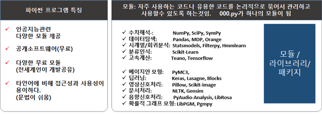

- 파이썬은 사용자 친화적이다.
  - 직관적이고, 깔끔하며, 체계적이며, 사용하기 쉬운 특징을 가진다.
- 파이썬은 인기도 많고, 수요도 높다.
  - 8만 7천명의 개발자가 참여한 스택오버플로(StackOverflow)의 개발자 설문조사에 따르면, 파이썬(Python)은 자바스크립트와, HTML/CSS, SQL 다음으로 인기있는 기술이다. 이외에도 세계에서 두 번째로 인기가 많으며, 수요는 가장 높은 언어로 뽑히기도 했다.
- 파이썬은 범용성을 지닌 언어이다.
  - 윈도우나 맥OS, 리눅스 등 어떠한 환경이든 관계없이, 파이썬은 거의 모든 개발 시나리오에서 사용될 수 있다.
  - Python은 게임, 프로그래밍 언어 개발, 프로토타입 제작, 그래픽 디자인 응용프로그램, 웹 프레임워크 등의 다양한 분야에서 핵심적인 역할을 하며, 최근에는 데이터 사이언스(data science) 및 머신러닝(ML) 분야에서 사용되는 핵심 언어 중 하나로 인기를 끌고 있다.
  - 파이썬은 단순하면서도 고급 언어이기 때문에, 머신러닝 알고리즘을 위한 빠른 프로토타입 제작과 수정 작업을 가능하게 해준다.

### 파이썬 실습할 수 있는 여러 가지 방법

  ### 미니콘다 설치
  1. 윈도 사용자 이름은 반드시 영문(0), 한글(x)
     - 사용자 계정 만들기 단축키: netplwiz (반드시 영문이름의 관리자 계정으로 만듬)
  2. 윈도 버전 및 시스템 종류 확인 (예: Windows10, 64bit)
     - [내 컴퓨터] 우클릭 > [속성]클릭
  3. 기본 웹브라우저 "크롬(Chrome)"으로 지정함
     - 시작-'기본 앱'-'웹 브라우저' 'Chrome'으로 지정
  4. 미니콘다 설치
     - 미니콘다 다운로드 : https://docs.conda.io/en/latest/miniconda.html

  ### 가상환경

  > 프로젝트별 python버전 및 기타 패키지 버전을 다르게 사용하고자 할 때

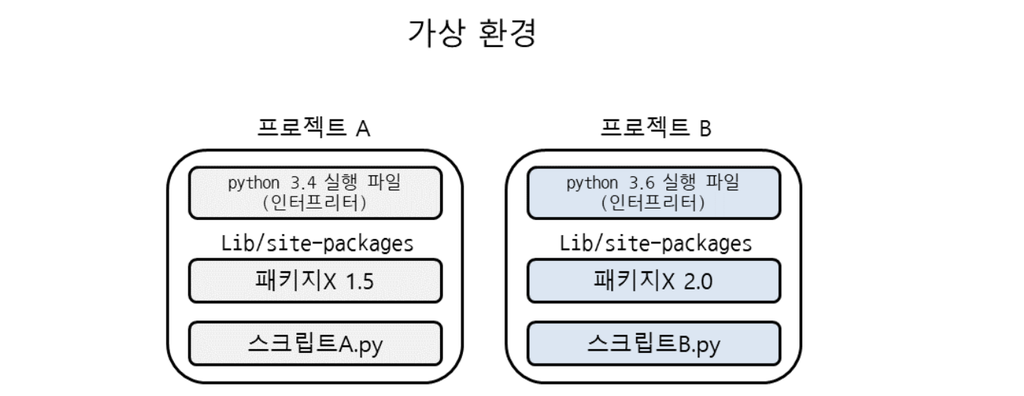

#### 1. 가상환경 만들기

1. [시작]-[Anaconda Prompt (Miniconda3)]
2. 가상환경 만들기
   > - 기본 명령: conda create -n 가상환경명 python=파이썬 버전
   > - 예) conda create -n smart python=3.9

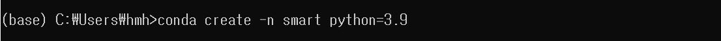

3. 가상환경 확인 : conda info --envs
4. 가상환경 활성화
   > - 기본 명령: activate 가상환경명
   > - 예) activate smart

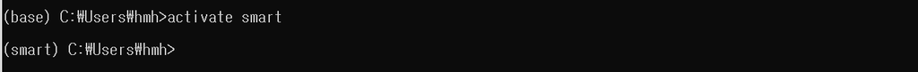

5. 기본 패키지 설치
   > - 쥬피터 노트북 설치: conda install jupyter

[figure not shown]

   > - 기본 패키지 설치: numpy, scipy, pandas, matplotlib, seaborn, scikit-learn, pillow  
   >   예) pip install numpy scipy pandas matplotlib seaborn scikit-learn pillow

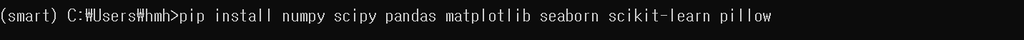

6. 주피터 노트북 실행
- 명령 터미널에서 실행: jupyter notebook

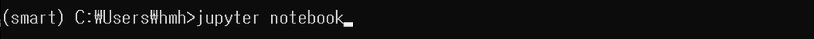

- 시작 메뉴에서 실행: [시작] > Jupyter Notebook(smart)
1. 기타 명령어
   > - conda 및 pip 업데이트:
   >   - conda update conda
   >   - pip install --upgrade pip
   > - 설치된 패키지 목록 확인: conda list 또는 pip list
   > - 설치된 패키지 목록 및 버전 확인: pip freeze
   > - 특정 패키지 버전 확인 : pip show [패키지 명]
   > - 파이썬 버전 확인: python --version
   > - 패키지 업데이트: pip install [패키지명] --upgrade
   > - 패키지 제거 : conda uninstall [패키지명] 또는 pip uninstall [패키지명]
   > - 기본 base 환경으로 나가기: deactivate

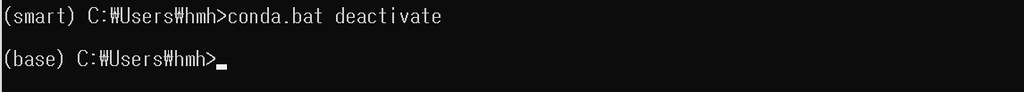

   > - 가상환경 삭제: conda env remove --n 가상환경명

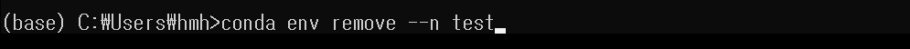

2. 패키지 목록 관리하기
   > - 자주 사용하는 패키지는 목록으로 만들어 두고 사용하면 편리함 (requirements.txt)
   > - 설치된 패키지 requirements.txt로 저장하기 : pip freeze > requirements.txt

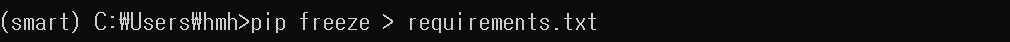

   > - requirements.txt 내용대로 패키지 설치: pip install -r requirements.txt
   > - requirements.txt 내용대로 패키지 삭제: pip uninstall -r requirements.txt